# Practical 1: Medical Databases_old

Nathan Smith

20/05/2022

Understanding the data

## Question 1

Variables descriptions:

PatientID is a unique patient identifier AppointmentID is a unique appointment identifier Gender: male or female (patient) ScheduledDate: date the appointment was scheduled AppointmentDate: date the appointment took place Age: Patient age in years Neighbourhood: Area in which the appointment took place SocialWelfare: Patient receives social welfare (Bolsa Família) Hypertension: Patient has been previously diagnosed with hypertension (Boolean) Diabetes: Patient has been previously diagnosed with diabetes (Boolean) AlcoholUseDisorder: Patient has been previously diagnosed with alcohol use disorder (Boolean) Disability: Patient has been previously diagnosed with a disability (severity rated 0-4) SMSReceived: At least 1 reminder text was sent before the appointment (Boolean) NoShow: Patient did not attend scheduled appointment (Boolean: Yes/No)

## Question 2

Three hypotheses as to why people may miss medical appointments:

1. Poor scheduling/no reminders
2. Distrust in the medical system
3. Local events, fear of safety (political instability, COVID, etc.)

## Question 3

Contextual information missing in the data dictionary that could impact analyses:

1. Appointment type not specified
2. Appointment time of day could play a role (missing)
3. Time since diagnoses (hypertension, diabetes, disability, and alcohol use disorder)
4. No physician ID or clinic ID, which could be informative
5. Is Bolsa Família welfare the only kind of welfare available in these areas?

## Question 4

Modify code to make reproducible:

```r
raw.data <- read_csv('https://raw.githubusercontent.com/nsmith91/CSCI6903_NS/main/2016_05v2_VitoriaAppointmentData.csv')#, col_types='ccfTTicllllflf')
```

## Question 5

Are there any individuals with impossible ages?

```
## # A tibble: 5 x 14
##   PatientID AppointmentID Gender ScheduledDate       AppointmentDate       Age
##       <dbl>         <dbl> <chr>  <dttm>              <dttm>              <dbl>
## 1   3.20e13       5700278 F      2016-05-16 09:17:44 2016-05-19 00:00:00   115
## 2   3.20e13       5700279 F      2016-05-16 09:17:44 2016-05-19 00:00:00   115
## 3   3.20e13       5562812 F      2016-04-08 14:29:17 2016-05-16 00:00:00   115
## 4   3.20e13       5744037 F      2016-05-30 09:44:51 2016-05-30 00:00:00   115
## 5   7.48e14       5717451 F      2016-05-19 07:57:56 2016-06-03 00:00:00   115
## # ... with 8 more variables: Neighbourhood <chr>, SocialWelfare <dbl>,
## #   Hypertension <dbl>, Diabetes <dbl>, AlcoholUseDisorder <dbl>,
## #   Disability <dbl>, SMSReceived <dbl>, NoShow <chr>
```

```
## # A tibble: 1 x 14
##   PatientID AppointmentID Gender ScheduledDate       AppointmentDate       Age
##       <dbl>         <dbl> <chr>  <dttm>              <dttm>              <dbl>
## 1   4.66e14       5775010 F      2016-06-06 08:58:13 2016-06-06 00:00:00    -1
## # ... with 8 more variables: Neighbourhood <chr>, SocialWelfare <dbl>,
## #   Hypertension <dbl>, Diabetes <dbl>, AlcoholUseDisorder <dbl>,
## #   Disability <dbl>, SMSReceived <dbl>, NoShow <chr>
```

Assuming babies can be counted as patients (age=0), there is only one age value that doesn’t make sense, with a value of -1

```r
data <- raw.data %>% filter(Age>=0)
```

```
## # A tibble: 1 x 3
##   Hypertension Diabetes AlcoholUseDisorder
##          <dbl>    <dbl>              <dbl>
## 1            0        0                  0
```

```
## # A tibble: 81 x 2
##    Neighbourhood         n
##    <chr>             <int>
##  1 JARDIM CAMBURI     7717
##  2 MARIA ORTIZ        5805
##  3 RESISTÊNCIA        4431
##  4 JARDIM DA PENHA    3877
##  5 ITARARÉ            3514
##  6 CENTRO             3334
##  7 TABUAZEIRO         3132
##  8 SANTA MARTHA       3131
##  9 JESUS DE NAZARETH  2853
## 10 BONFIM             2773
## # ... with 71 more rows
```

```
## # A tibble: 62,299 x 2
##    PatientID     n
##        <dbl> <int>
##  1   8.22e14    88
##  2   9.96e10    84
##  3   2.69e13    70
##  4   3.35e13    65
##  5   2.58e11    62
##  6   6.26e12    62
##  7   7.58e13    62
##  8   8.71e14    62
##  9   6.68e13    57
## 10   8.72e11    55
## # ... with 62,289 more rows
```

## Question 6

What is the maximum number of visits from the same patient?

The maximum number is 88

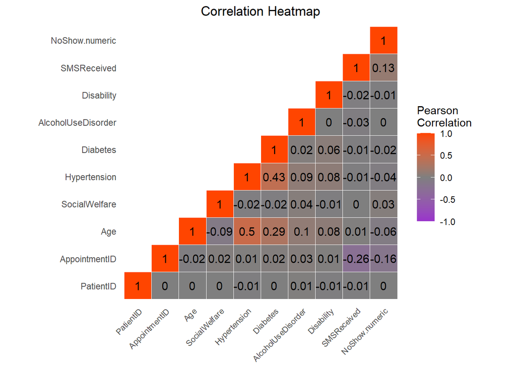

## Question 8

Are there any other variables which strongly correlate with one another?

## Question 9

Do you see any issues with PatientID/AppointmentID being included in this plot?

Yes, PatientID and AppointmentID are unique ID variables, not numerical data. These correlations merely suggest how the IDs were generated/assigned.

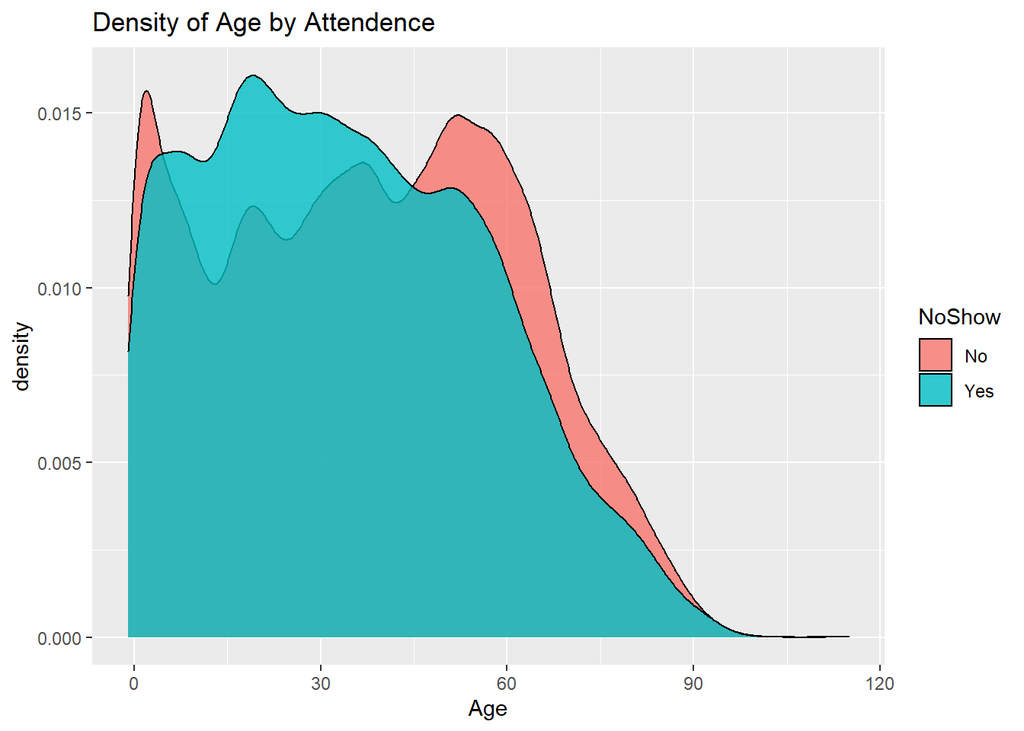

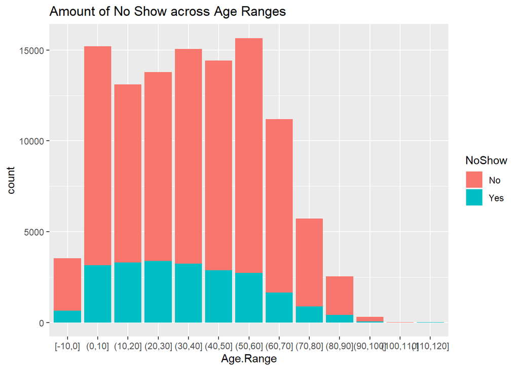

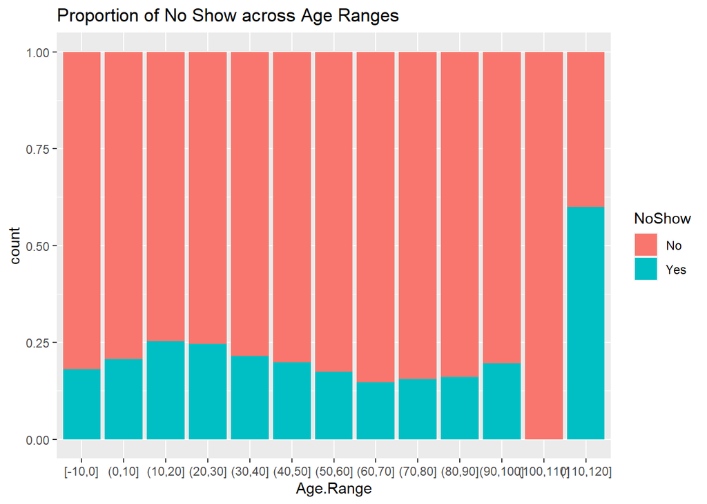

## Question 10

How could you be misled if you only plotted 1 of these 2 plots of attendance by age group?

Only plotting proportion can be misleading because we do not have the total counts, so the age categories with very small numbers do not accurately reflect those age groups (such as 90-100, 110-120). Whereas only looking at total counts may be difficult to visually compare proportions.

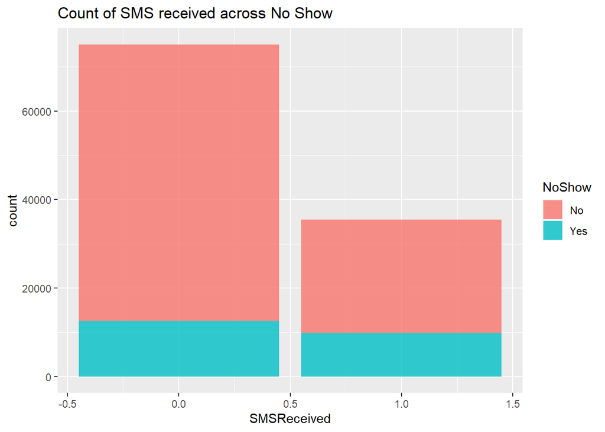

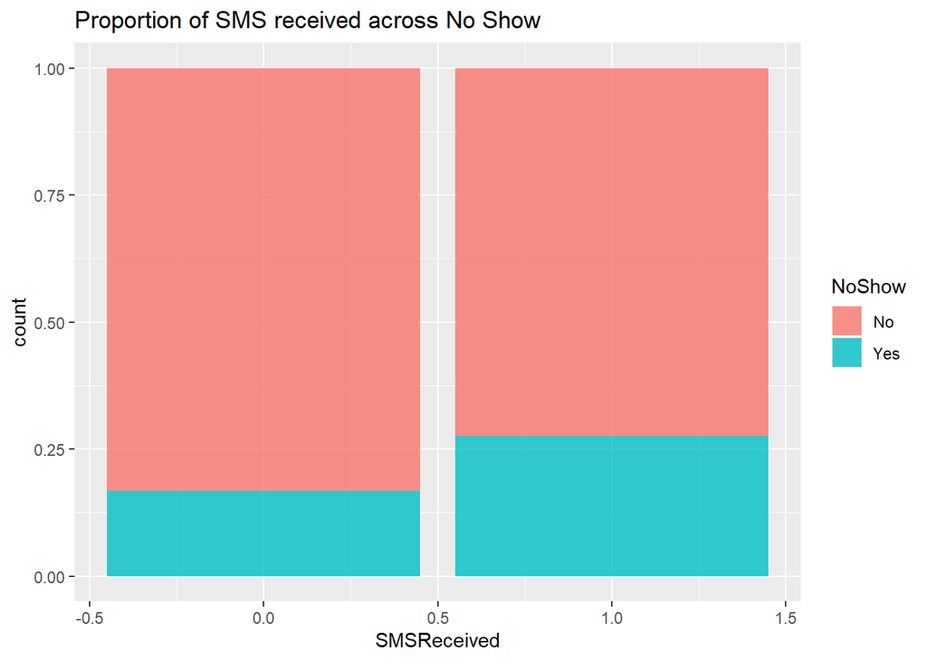

## Question 11

From this plot does it look like SMS reminders increase or decrease the chance of someone not attending an appointment? Why might the opposite actually be true (hint: think about biases)? From these plots it looks like SMSReceived increases the chance of a NoShow. This may be because the places that send SMS reminders may also have other factors that increase the likelihood of a Noshow. I.e., the places that send texts may be systematically different in some way which makes it less likely that individuals will attend the appointment.

## Question 12

Create a similar plot which compares the the density of NoShow across the values of disability

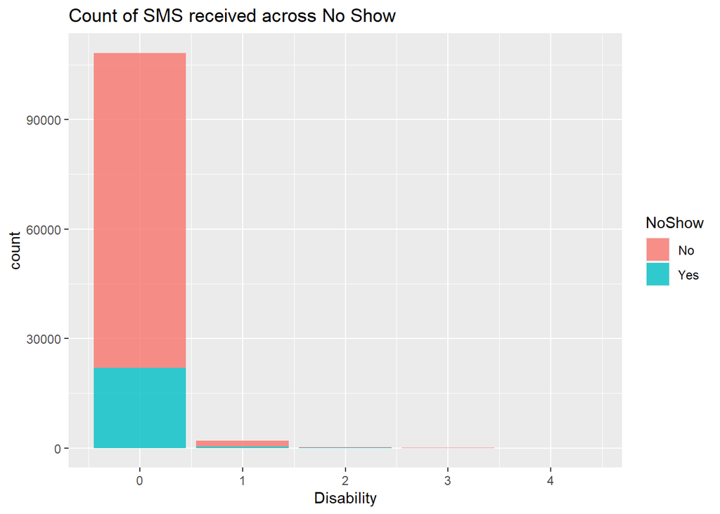

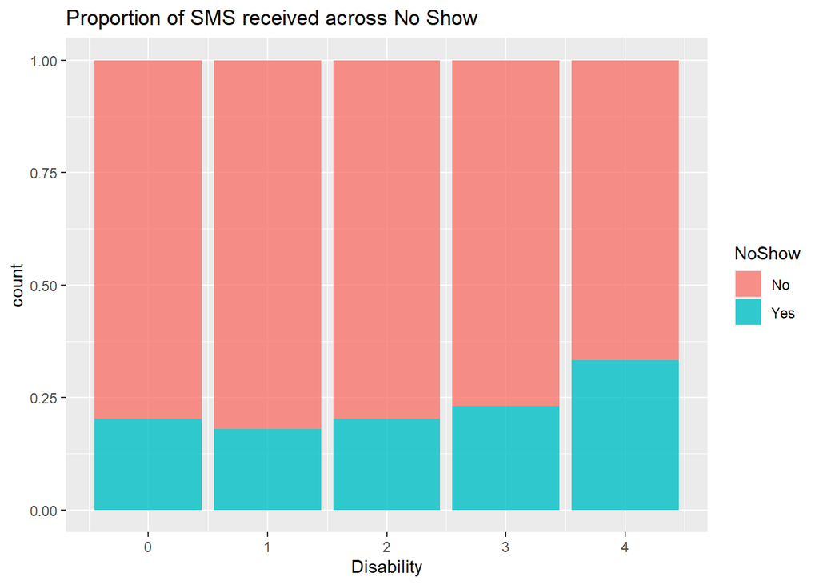

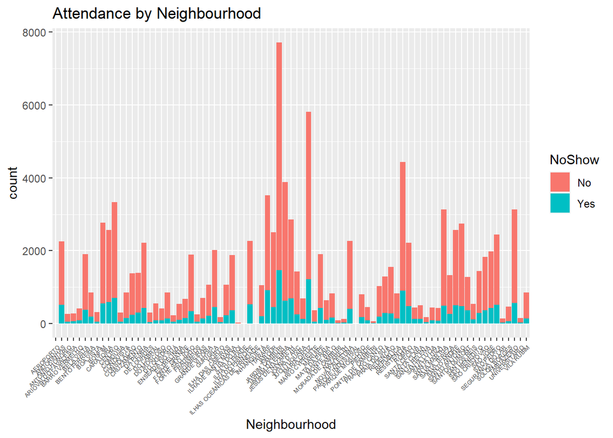

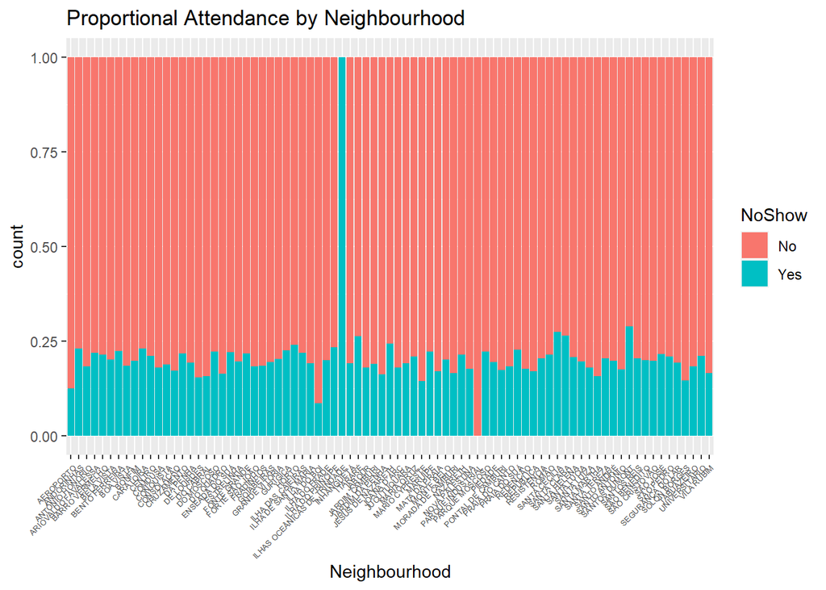

## Question 13

Suggest a reason for differences in attendance rates across neighbourhoods.

Different neighbourhoods may have different characteristics that affect attendance- different kinds of clinics and appointments, different physical environments, different transportation options/ differing accessibility, differing SES of patients.

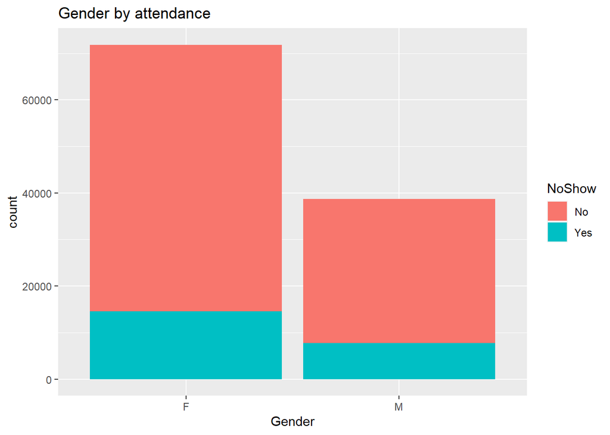

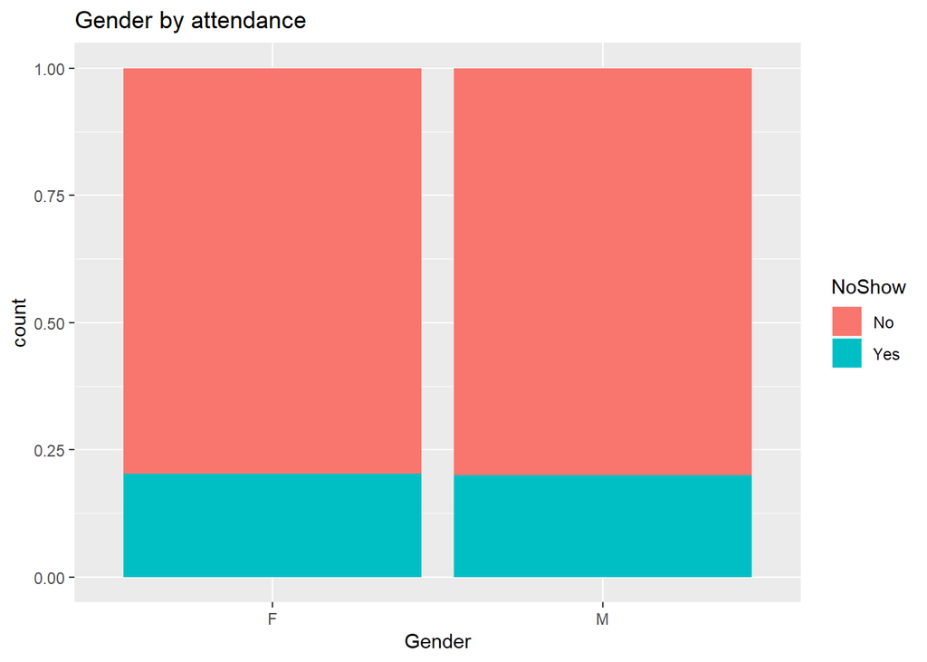

## Question 14

Create a similar plot using SocialWelfare

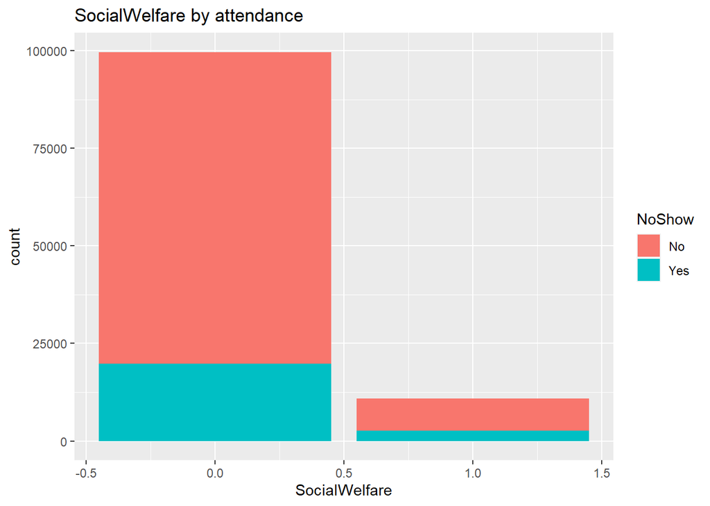

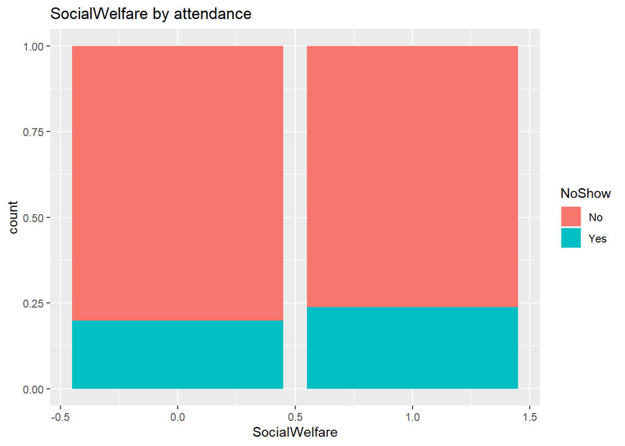

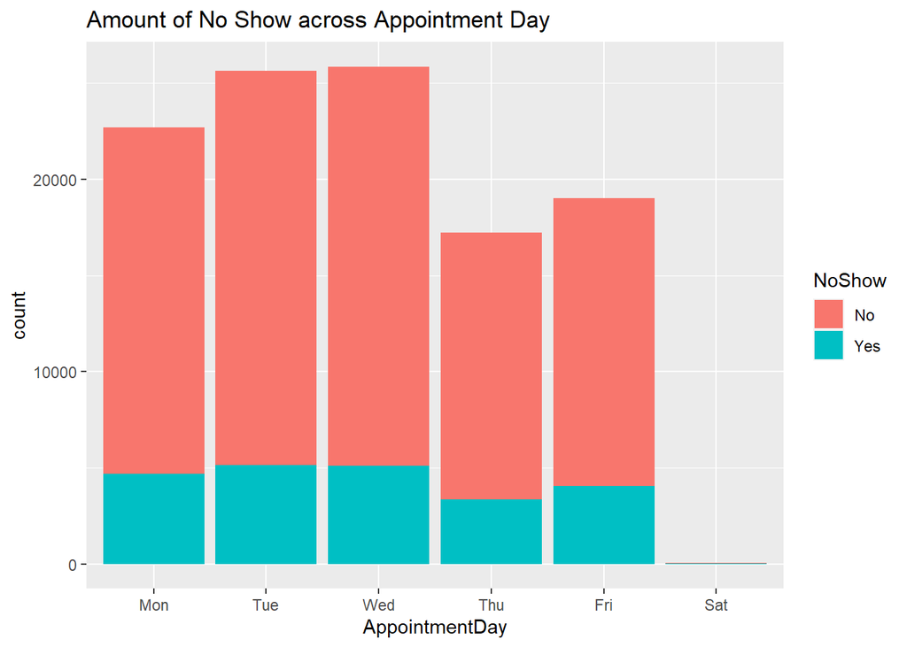

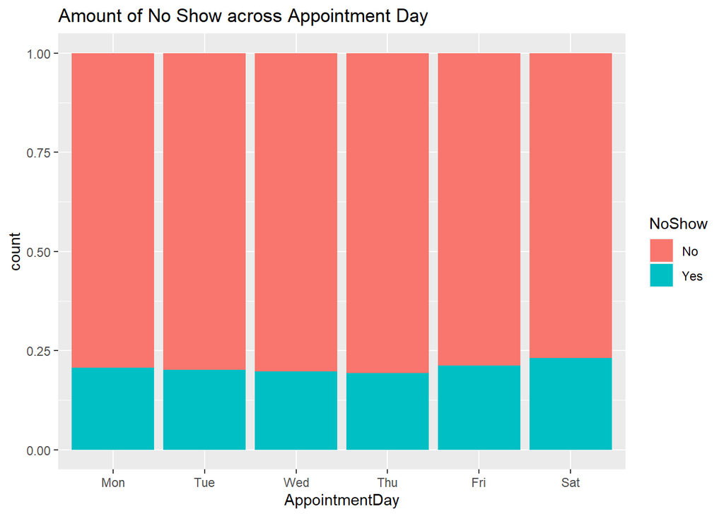

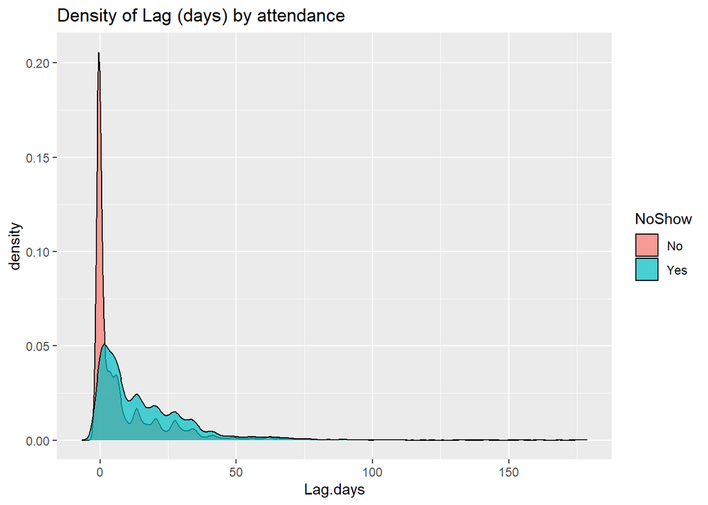

## Question 15

Have a look at the values in lag variable, does anything seem odd?

We have both positive and negative values for lag days (the number of days between the schedule date and the appointment date), which means sometimes the appointment was scheduled after the date it took place?

## Question 16

Based on the exploratory data analysis, how well do you think this is going to work?

I think it’s hard to say how well it will work given the limited EDA performed- nothing immediately stood out (association-wise) and we seemingly have some data inconsistencies (e.g., positive and negative lag days). There is some contextual information missing in the data which may have been helpful- I would guess it will perform moderately well. **

**Note- I was getting errors when trying to run your code- even after you adjusted my code I still had to drop one observation to get it to run:**

```r
errorlist <- data.prep %>%
  filter(Neighbourhood == "PARQUE INDUSTRIAL")
  print(errorlist)
```

```
## # A tibble: 1 x 18
##   Gender ScheduledDate       AppointmentDate       Age Neighbourhood
##   <chr>  <dttm>              <dttm>              <dbl> <chr>
## 1 F      2016-05-05 10:48:59 2016-05-05 00:00:00    17 PARQUE INDUSTRIAL
## # ... with 13 more variables: SocialWelfare <dbl>, Hypertension <dbl>,
## #   Diabetes <dbl>, AlcoholUseDisorder <dbl>, Disability <dbl>,
## #   SMSReceived <dbl>, NoShow <chr>, NoShow.numeric <dbl>, Age.Range <fct>,
## #   AppointmentDay <ord>, ScheduledDay <ord>, Lag.days <drtn>, Lag.hours <drtn>
```

```r
data.prep1<-subset(data.prep, Neighbourhood!="PARQUE INDUSTRIAL")
```

```r
#Remake the test and train split:
set.seed(42)
data.split <- initial_split(data.prep1, prop = 0.7)
train  <- training(data.split)
test <- testing(data.split)
```

```r
xgb.grid <- expand.grid(eta=c(0.05),
                       max_depth=c(4),colsample_bytree=1,
                       subsample=1, nrounds=500, gamma=0, min_child_weight=5)

xgb.model <- train(NoShow ~ .,data=train, method="xgbTree",metric="ROC",
                  tuneGrid=xgb.grid, trControl=fit.control)

xgb.pred <- predict(xgb.model, newdata=test)
xgb.probs <- predict(xgb.model, newdata=test, type="prob")
```

```r
test <- test %>% mutate(NoShow.numerical = ifelse(NoShow=="Yes",1,0))
confusionMatrix(xgb.pred, as.factor(test$NoShow), positive="Yes")
```

```
## Confusion Matrix and Statistics
##
##           Reference
## Prediction    No   Yes
##        No  26516     0
##        Yes     0  6642
##
##                Accuracy : 1
##                  95% CI : (0.9999, 1)
##     No Information Rate : 0.7997
##     P-Value [Acc > NIR] : < 2.2e-16
##
##                   Kappa : 1
##
##  Mcnemar's Test P-Value : NA
##
##             Sensitivity : 1.0000
##             Specificity : 1.0000
##          Pos Pred Value : 1.0000
##          Neg Pred Value : 1.0000
##              Prevalence : 0.2003
##          Detection Rate : 0.2003
##    Detection Prevalence : 0.2003
##       Balanced Accuracy : 1.0000
##
##        'Positive' Class : Yes
##
```

For some reason this chunk of code gave me an error during rendering:

paste(“XGBoost Area under ROC Curve:”, round(auc(test$NoShow.numerical, xgb.probs[,2]),3), sep=““)

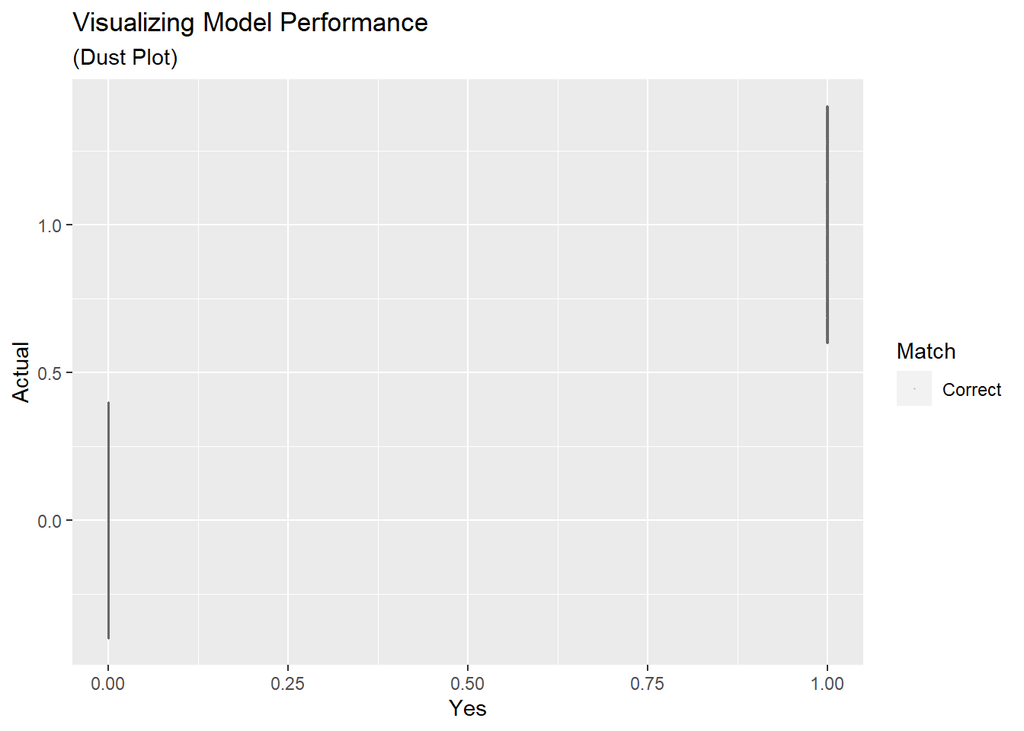

Finally, let’s close it off with the variable importance of our model:

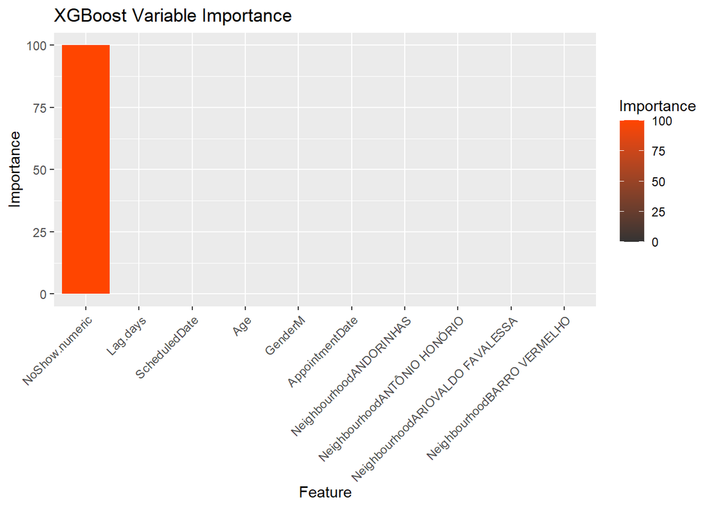

## Question 17

Using the [caret package](https://topepo.github.io/caret/) fit and evaluate 1 other ML model on this data.

I tried a few different models but kept getting errors, and was unable to get one suuccessfully troubleshoot the errors

## Question 18

Based on everything, do you think we can trust analyses based on this dataset? Explain your reasoning.